# Bikeshare/Weather Model

Tyler Yankee

2022-12-07

This analysis was performed with help from the tutorial from Data Science in a Box found here: https://minecr.shinyapps.io/dsbox-06-dcbikeshare/.

## Load packages

```r
library(tidyverse)
library(tidymodels)
library(dsbox)
```

## Clean data

- Recode the `season` variable from numeric values to names, and order them based on the year
- Recode the `holiday` and `workingday` variables from 0/1 to “no/yes”
- Recode the `yr` variable as the absolute year rather than number of years since 2011
- Recode the `weathersit` variable to a description of the weather rather than a number

```r
dcbikeshare <- dcbikeshare %>% mutate(season = case_when(
    season == 1 ~ "winter",
    season == 2 ~ "spring",
    season == 3 ~ "summer",
    season == 4 ~ "fall"),
    season = fct_relevel(season, "spring", "summer", "fall", "winter"))

dcbikeshare <- dcbikeshare %>% mutate(
    holiday = ifelse(holiday == 0, "no", "yes"),
    holiday = fct_relevel(holiday, "no", "yes"),
    workingday = ifelse(workingday == 0, "no", "yes"),
    workingday = fct_relevel(workingday, "no", "yes"))

dcbikeshare <- dcbikeshare %>% mutate(
    yr = ifelse(yr == 0, "2011", "2012"),
    yr = fct_relevel(yr, "2011", "2012"))

dcbikeshare <- dcbikeshare %>% mutate(
    weathersit = case_when(
    weathersit == 1 ~ "clear",
    weathersit == 2 ~ "mist",
    weathersit == 3 ~ "light precipitation",
    weathersit == 4 ~ "heavy precipitation"),
    weathersit = fct_relevel(weathersit, "clear", "mist",
                             "light precipitation", "heavy precipitation"))
```

## New variables

- Create raw values for temperature, humidity, and windspeed
- Check that the sum of `casual` and `registered` adds up to the total `cnt`

```r
dcbikeshare <- dcbikeshare %>% mutate(
    temperature_raw = temp * 41,
    feeling_temperature_raw = atemp * 50,
    humidity_raw = hum * 100,
    windspeed_raw = windspeed * 67)

dcbikeshare %>% mutate(cas_plus_reg = casual + registered) %>%
  summarise(all_zero = all(cas_plus_reg == cnt))
```

| all_zero |
| --- |
| TRUE |

## Visualizations

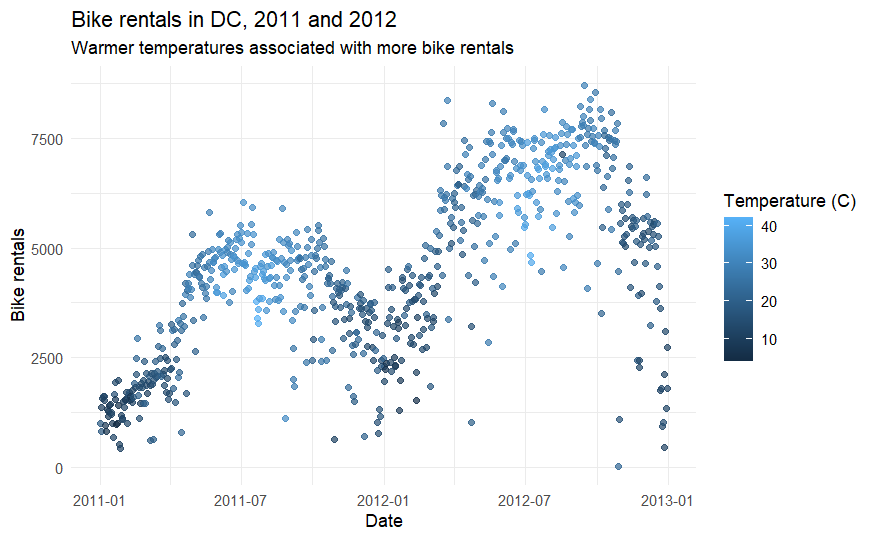

```r
dcbikeshare %>% ggplot(aes(x = dteday, y = cnt, color = feeling_temperature_raw)) +
    geom_point(alpha = .7) +
    labs(title = "Bike rentals in DC, 2011 and 2012",
         subtitle = "Warmer temperatures associated with more bike rentals",
         x = "Date", y = "Bike rentals", color = "Temperature (C)") +
  theme_minimal()
```

## Fitting a model to the data

```r
cnt_tmp <- linear_reg() %>%
  set_engine("lm") %>%
  fit(cnt ~ temperature_raw, data = dcbikeshare)
cnt_tmp %>%
  tidy()
```

| term | estimate | std.error | statistic | p.value |
| --- | --- | --- | --- | --- |
| (Intercept) | 1214.6421 | 161.163531 | 7.536706 | 1.432673e-13 |
| temperature_raw | 161.9685 | 7.443611 | 21.759405 | 2.810622e-81 |

```r
glance(cnt_tmp)$r.squared
```

```
[1] 0.3937487
```

A couple takeaways from the model:

- Since the slope parameter (for `temperature_raw`) is about 162, this means that for each additional degree Celsius, we can expect bike rentals to increase by about 162.
- The $R^2$ value of .394 indicates that 39.4% of the variability in the total number of daily bike rentals is accounted for by this model.

## New model

The model between `temperature_raw` and `cnt` wasn’t a very good fit - let’s take a look at `feeling_temperature_raw` (the feel-like temperature).

```r
cnt_atmp <- linear_reg() %>%
  set_engine("lm") %>%
  fit(cnt ~ feeling_temperature_raw, data = dcbikeshare)
cnt_atmp %>%
  tidy()
```

| term | estimate | std.error | statistic | p.value |
| --- | --- | --- | --- | --- |
| (Intercept) | 945.8240 | 171.291469 | 5.521723 | 4.671196e-08 |
| feeling_temperature_raw | 150.0367 | 6.830765 | 21.964843 | 1.854504e-82 |

```r
glance(cnt_atmp)$r.squared
```

```
[1] 0.3982439
```

With an $R^2$ value of .398, this model is *slightly* better at capturing the data than the previous model, but not by much.

## Full model

Let’s include all variables impacting the total bike count: `season`, `yr`, `holiday`, `workingday`, `weathersit`, `temperature_raw`, `feeling_temperature_raw`, `humidity_raw`, `windspeed_raw`, and the interaction between `feeling_temperature_raw` and `holiday`.

```r
cnt_full <- linear_reg() %>%
  set_engine("lm") %>%
  fit(cnt ~ season + yr + holiday + workingday + weathersit +
  temperature_raw + feeling_temperature_raw + humidity_raw +
  windspeed_raw + feeling_temperature_raw * holiday, data = dcbikeshare)
tidy(cnt_full)
```

| term | estimate | std.error | statistic | p.value |
| --- | --- | --- | --- | --- |
| (Intercept) | 2715.14054 | 268.533836 | 10.1109811 | 1.475889e-22 |
| seasonsummer | -276.94853 | 100.344540 | -2.7599761 | 5.928162e-03 |
| seasonfall | 409.79210 | 96.164571 | 4.2613626 | 2.303159e-05 |
| seasonwinter | -1130.56069 | 113.544157 | -9.9570134 | 5.795629e-22 |
| yr2012 | 2014.06598 | 61.704875 | 32.6403057 | 6.375959e-144 |
| holidayyes | -1384.37860 | 495.409135 | -2.7944148 | 5.338259e-03 |
| workingdayyes | 119.67853 | 67.867412 | 1.7634167 | 7.825612e-02 |
| weathersitmist | -420.24376 | 81.285535 | -5.1699698 | 3.039898e-07 |
| weathersitlight precipitation | -1907.14902 | 207.547189 | -9.1889899 | 4.207726e-19 |
| temperature_raw | 102.99712 | 34.014628 | 3.0280243 | 2.549875e-03 |

[output cut: 4 more lines]

```r
glance(cnt_full)$adj.r.squared
```

```
[1] 0.8201774
```

Observations:

- The $R^2$ is much higher for this model, which is a good result.
- Interesting notes on holidays: the intercept for non-holidays is higher than that for holidays, while the slope for feeling_temperature is steeper for holidays than for non-holidays.
- Based on the slope parameters, the season with the highest number of bike rentals appears to be the fall, while the season with the lowest is winter.

## Backward selection

Now that we’ve made a model with all of the explanatory variables, let’s explore removing each of them one by one to see if that provides a better fit.

Without `season`

```r
rm_season <- linear_reg() %>%
  set_engine("lm") %>%
  fit(cnt ~ yr + holiday + workingday + weathersit +
  temperature_raw + feeling_temperature_raw + humidity_raw +
  windspeed_raw + feeling_temperature_raw * holiday, data = dcbikeshare)
glance(rm_season)$adj.r.squared
```

```
[1] 0.7491125
```

Without `year`

```r
rm_year <- linear_reg() %>%
  set_engine("lm") %>%
  fit(cnt ~ season + holiday + workingday + weathersit +
  temperature_raw + feeling_temperature_raw + humidity_raw +
  windspeed_raw + feeling_temperature_raw * holiday, data = dcbikeshare)
glance(rm_year)$adj.r.squared
```

```
[1] 0.5536019
```

Without `holiday` (and interaction between `holiday` and `feeling_temperature_raw`)

```r
rm_holiday <- linear_reg() %>%
  set_engine("lm") %>%
  fit(cnt ~ season + yr + workingday + weathersit +
  temperature_raw + feeling_temperature_raw + humidity_raw +
  windspeed_raw, data = dcbikeshare)
glance(rm_holiday)$adj.r.squared
```

```
[1] 0.8172787
```

Without `weathersit`

```r
rm_weathersit<- linear_reg() %>%
  set_engine("lm") %>%
  fit(cnt ~ season + yr + holiday + workingday +
  temperature_raw + feeling_temperature_raw + humidity_raw +
  windspeed_raw + feeling_temperature_raw * holiday, data = dcbikeshare)
glance(rm_weathersit)$adj.r.squared
```

```
[1] 0.7984698
```

Without `temperature_raw`

```r
rm_temp_raw<- linear_reg() %>%
  set_engine("lm") %>%
  fit(cnt ~ season + yr + holiday + workingday + weathersit +
  feeling_temperature_raw + humidity_raw +
  windspeed_raw + feeling_temperature_raw * holiday, data = dcbikeshare)
glance(rm_temp_raw)$adj.r.squared
```

```
[1] 0.8181315
```

Without `feeling_temperature_raw` (and interaction between `feeling_temperature_raw` and `holiday`)

```r
rm_feeltemp_raw <- linear_reg() %>%
  set_engine("lm") %>%
  fit(cnt ~ season + yr + holiday + workingday + weathersit +
  temperature_raw + humidity_raw +
  windspeed_raw, data = dcbikeshare)
glance(rm_feeltemp_raw)$adj.r.squared
```

```
[1] 0.8198807
```

Without `humidity_raw`

```r
rm_humidity_raw <- linear_reg() %>%
  set_engine("lm") %>%
  fit(cnt ~ season + yr + holiday + workingday + weathersit +
  temperature_raw + feeling_temperature_raw +
  windspeed_raw + feeling_temperature_raw * holiday, data = dcbikeshare)
glance(rm_humidity_raw)$adj.r.squared
```

```
[1] 0.8151378
```

Without `windspeed_raw`

```r
rm_windspeed_raw <- linear_reg() %>%
  set_engine("lm") %>%
  fit(cnt ~ season + yr + holiday + workingday + weathersit +
  temperature_raw + feeling_temperature_raw + humidity_raw +
  feeling_temperature_raw * holiday, data = dcbikeshare)
glance(rm_windspeed_raw)$adj.r.squared
```

```
[1] 0.8106108
```

Without interaction between `feeling_temperature_raw` and `holiday`

```r
rm_interaction <- linear_reg() %>%
  set_engine("lm") %>%
  fit(cnt ~ season + yr + holiday + workingday + weathersit +
  temperature_raw + feeling_temperature_raw + humidity_raw +
  windspeed_raw, data = dcbikeshare)
glance(rm_interaction)$adj.r.squared
```

```
[1] 0.8197295
```

Observations:

- When observing the adjusted $R^2$ of all of the above and comparing that to the $R^2$ of the full model, we can conclude that none of these models provide a significant improvement over the full model.